# Explore Demand of bike sharing in Souel

by Team-Name: User1, User2, User3, User4 & User5

2026-11-27

## Introduction

Urban shared Bicycles provides a rich context for exploring enhancement of mobility comfort.Weather data and holiday information factors may affect rental demand.

**To what extent do time of day, temperature and holiday status relate to the rentals of sharing bike in Seoul?**

## Data Overview

The dataset comprises 8760 instances and 13 features drawn from Seoul Bike Sharing System. Each observation records rented bike count, rented hours, temperature, date type and other information.

|**Variable**|**Type**|**Description**|

|hour|Numeric|The hour of the day,ranging from 0 to 23|

|season|Categorical|The season of the year: Spring, Summer,Autumn,Winter|

|temperature|Numeric|measured in degree Celsius|

|humidity|Numeric|relative humidity,expressed as a percentage %|

|rainfall|Numeric|measured in millimeters (mm)|

|holiday|Categorical|wheter holiday or not(TRUE/FALSE)|

## Data Visualisations

### 1.Rental denmand in different hours of day

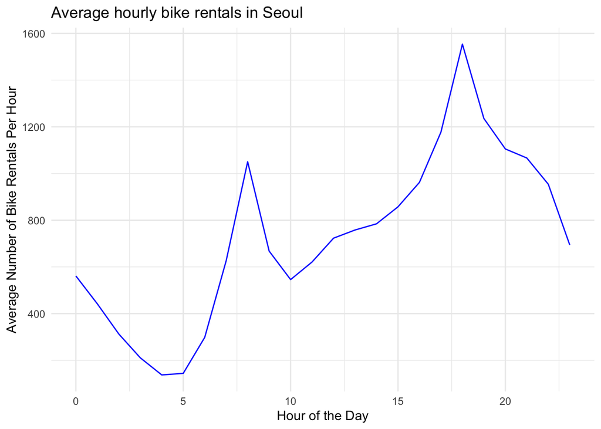

The graph shows a consistent bimodal trend: two clear peaks appear during morning and evening commuting hours, while demand is lowest in the early morning.

[output not shown]

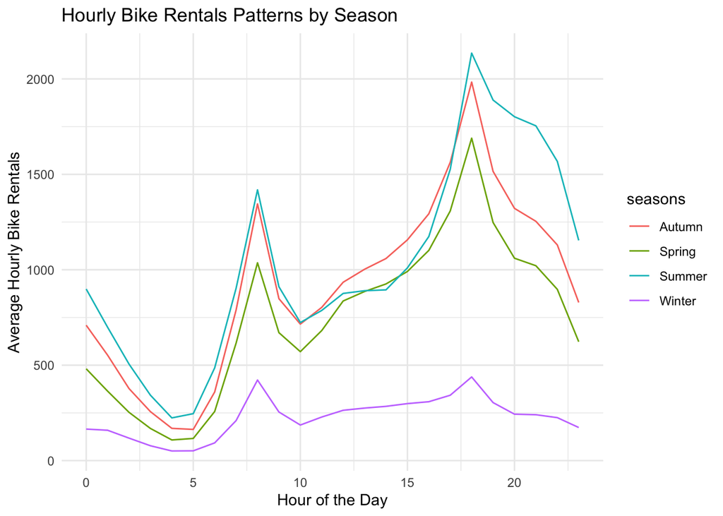

We plot the average hourly bike rentals against the hour of the day combined with changes in the season. Average bike rentals peak in summer, are moderately high in autumn and spring, but drop sharply in winter. This suggests that weather conditions,such as temperature, storngly influence cycling activity alongside commuting behaviour.

### 2.Impact of weather conditions

The scatter plot with a LOESS smoother shows a positive, non‑linear association:bike rentals generally rise with increasing temperature, but after a certain point, demand begins to fall when it becomes too hot.

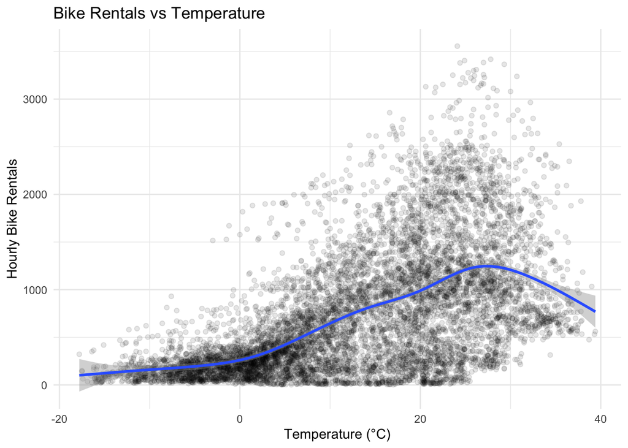

While warmer temperatures generally encourage cycling, extreme heat reduces rental demand. Rainfall is another important weather factor that may suppress bike use.

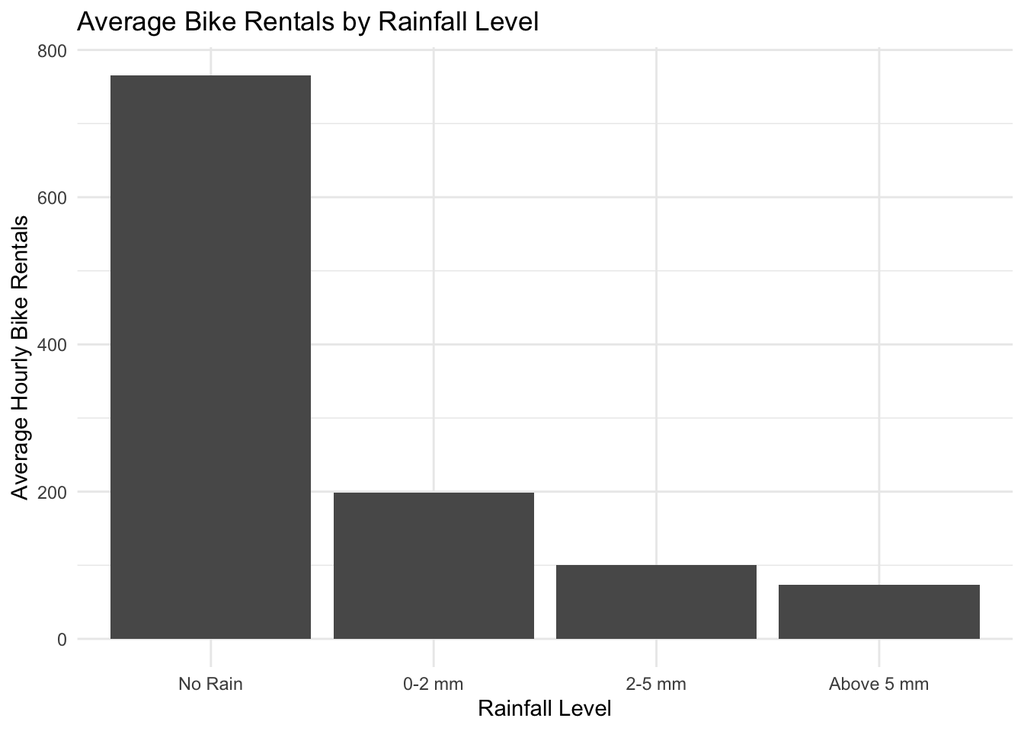

Bar chart showing average hourly bike rentals grouped by rainfall level, indicating lower demand with heavier rain.

## Regression Analysis

### Model choice

Our target variable is the hourly number of bike rentals, a continuous outcome, so we choose linear regression.We built three linear regression models incrementally to examine the drivers of bike rental demand. The first model uses only temperature as the predictor. The second extends the model by adding humidity and rain status. The final full model incorporates weather variables together with hour, season and holiday status, to capture both weather effects and temporal patterns.

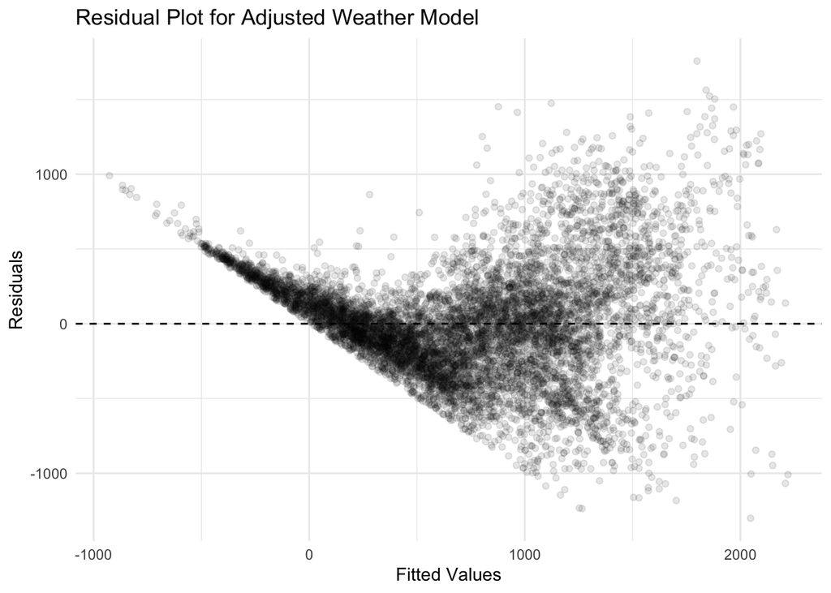

```
## # A tibble: 1 × 12
##   r.squared adj.r.squared sigma statistic p.value    df  logLik     AIC     BIC
##       <dbl>         <dbl> <dbl>     <dbl>   <dbl> <dbl>   <dbl>   <dbl>   <dbl>
## 1     0.317         0.317  531.     3922.       0     1 -65127. 130259. 130280.
## # ℹ 3 more variables: deviance <dbl>, df.residual <int>, nobs <int>
```

```
## # A tibble: 1 × 12
##   r.squared adj.r.squared sigma statistic p.value    df  logLik     AIC     BIC
##       <dbl>         <dbl> <dbl>     <dbl>   <dbl> <dbl>   <dbl>   <dbl>   <dbl>
## 1     0.433         0.432  484.     2151.       0     3 -64339. 128688. 128723.
## # ℹ 3 more variables: deviance <dbl>, df.residual <int>, nobs <int>
```

```
## # A tibble: 1 × 12
##   r.squared adj.r.squared sigma statistic p.value    df  logLik     AIC     BIC
##       <dbl>         <dbl> <dbl>     <dbl>   <dbl> <dbl>   <dbl>   <dbl>   <dbl>
## 1     0.677         0.676  366.      589.       0    30 -61958. 123980. 124206.
## # ℹ 3 more variables: deviance <dbl>, df.residual <int>, nobs <int>
```

```
##                    Model R_squared Adjusted_R_squared  Sigma
## 1       Temperature Only     0.317              0.317 531.02
## 2          Weather Model     0.433              0.432 483.91
## 3 Adjusted Weather Model     0.677              0.676 365.85
```

```
##      Variable Weather_Model Adjusted_Weather_Model
## 1 Temperature         32.64                  24.46
## 2    Humidity         -7.33                  -5.63
## 3 Rain Status       -473.55                -522.56
```

According to Regression analysis Temperature only: Predicted hourly bike rentals = 348 + 29.9 × Temperature. Weather variables: Predicted hourly bike rentals = 767.33 + 32.64 × Temperature - 7.33 × Humidity - 473.55 × Rain Status

### 3.Rental patterns between holidays and non-holidays

This box plot compares total daily bike rentals on holidays and non‑holidays. It shows that the median daily rental volume is lower on holidays than on regular days. The spread of rental values also differs, suggesting that people’s cycling behaviour changes when it is a holiday.

[output not shown]

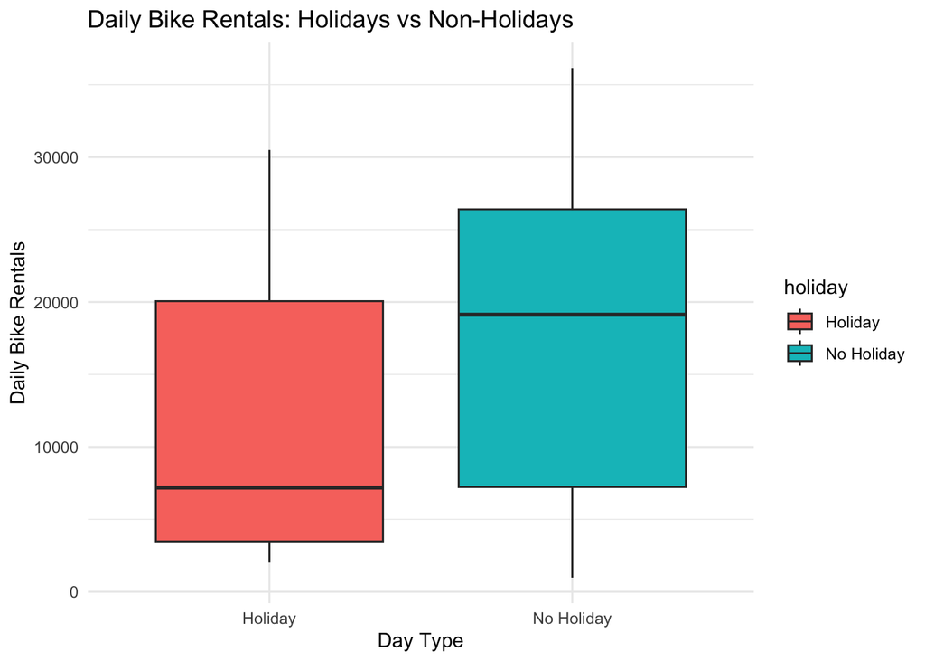

This box plot compares total daily bike rentals on holidays and non‑holidays. It shows that the median daily rental volume is lower on holidays than on regular days. The spread of rental values also differs, suggesting that people’s cycling behaviour changes when it is a holiday.

[output not shown]

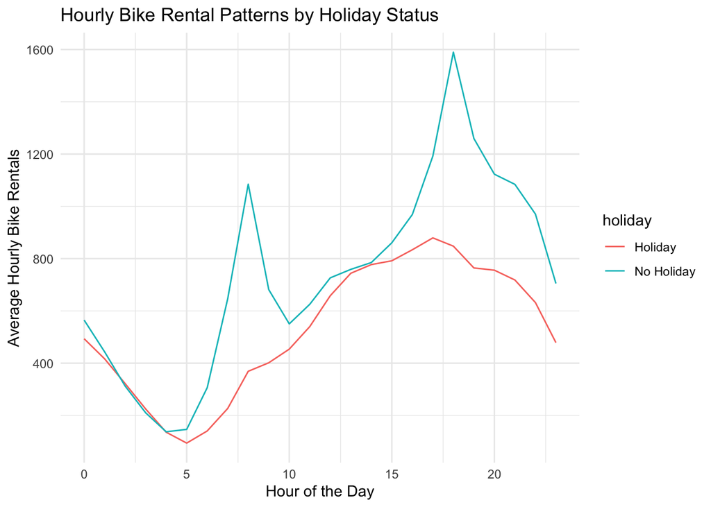

This line graph illustrates the average hourly bike rental profiles for holidays and non‑holidays across the day. On normal days, there are two distinct peaks corresponding to morning and evening commuting hours, with overall rental volumes generally higher. In contrast, the holiday curve is flatter, lacking sharp commuting peaks; demand rises gradually in the daytime and reaches a lower, broader peak in the afternoon. This indicates that holiday bike use is less driven by commuting and more for leisure.

## Limitations and Considerations

**Data Limitations**

1.As observational data,the database can only demonstrate correlations association rather than causal relationship. 2.The original database provides no information about users’ actual purpose. 3.The data is restricted to a single city and a limited time span,so findings may not generalize widely 4.Sample sizes of holiday and non-holiday are unequal.

**Model Limitations**

1.Variables including temperature,humidity,season and time of day are confounded with one another 2.Linear regression may not fully capture non-linear relationships between variables. 3.Hourly observations may violate rhw independence assumption due to temporal autocorrelation 4.Model performance was not evaluated on independent test data.

## Conclusion

Our analyses suggest that while weather, hour, season and holiday status do relate to bike rental demand, their explanatory power is limited. Extra variables (e.g. road conditions, public transport disruption or station availability) and more complex models could be considered in future to build better predictors for rental volume.

## References

Sathishkumar, V. E., Park, J., & Cho, Y. (2020). https://archive.ics.uci.edu/dataset/560/seoul+bike+sharing+demand